# Task 2

Max Settineri

2023-02-19

### Overview

This report looks at lizard pitfall trap data in the Jornada Basin LTER site in New Mexico from 1989-2006. This analysis will use non linear least squares (NLS) to estimate weight as a function of snout to vent length for lizard populations. An NLS model will be fit for weight and snout to vent length for all lizards in the data set; then NLS will be used again to fit a model for only male western whiptail lizards. The two models will then be compared to determine which is more effective.

**Data Citation:** Lightfoot, D. and W.G. Whitford. 2020. Lizard pitfall trap data from 11 NPP study locations at the Jornada Basin LTER site, 1989-2006 ver 37. Environmental Data Initiative. https://doi.org/10.6073/pasta/4a6e258fb49c31e222ecbbcfd128967f

```r
# Reading in and cleaning data
lizards <- read_csv(here("data", "lizards.csv")) %>%
  clean_names() %>%
  mutate(log_weight = log(weight)) %>% # log transforming the data - since we are using an exponential base equation
  mutate(log_length = log(sv_length)) %>%
  drop_na() %>%
  mutate(sex = case_when(
    sex == "M" ~ "Male",
    sex == "F" ~ "Female"
  ))
```

### Fitting snout length to weight model

**Equation**
$$W =
a(SVL)^b$$

- Where W is the Body weight (g), SVL is snout to vent length (mm).
- a and b are parameters which need to be fitted

```r
# running a guess model
guess_model <- lm(log_weight ~ log_length, data = lizards)

# pulling out the coefficients from the guess model
coef <- coefficients(guess_model)

# cleaning up the model to more easily pull out the coefficients
guess_model_tidy <- tidy(guess_model)

# storing a function of the model with coefficients
weight_function <- function(a, sv_length, b){
  weight = a*(sv_length)^b
  return(weight)
}
```

**Coefficient Output**

- The intercept of `guess_model` is -8.257
- The log_length of `guess_model` is 2.479

### Running NLS on the entire data set

```r
# feeding in estimated coefficients as starting point for nls
lizards_nls <- nls(weight ~ weight_function(a,sv_length,b),
                    data = lizards,
                    start = list(b = coef[2],
                                 a = exp(coef[1])))

# making a tidy model output
lizards_nls_tidy <- tidy(lizards_nls)
```

```r
# making a table with outputs
lizards_nls_tidy %>%
  mutate(p.value = case_when(p.value < 0.001 ~ '<0.001')) %>%
  kable(col.names = c('Term', 'Coefficient', 'Standard Error', 'Statistic', 'P Value'),
        digits = 4,
        caption = '<b>Table 1:</b> NLS Model Results') %>%
  kable_styling(bootstrap_options = c("striped", "hover")) %>%
  kable_styling(full_width = FALSE)
```

**Table 1:** NLS Model Results

| Term | Coefficient | Standard Error | Statistic | P Value |
| --- | --- | --- | --- | --- |
| b | 2.7210 | 0.0197 | 138.2642 | <0.001 |
| a | 0.0001 | 0.0000 | 11.7737 | <0.001 |

```r
# predicting data based on our NLS model
lizards_augment <- augment(lizards_nls)
```

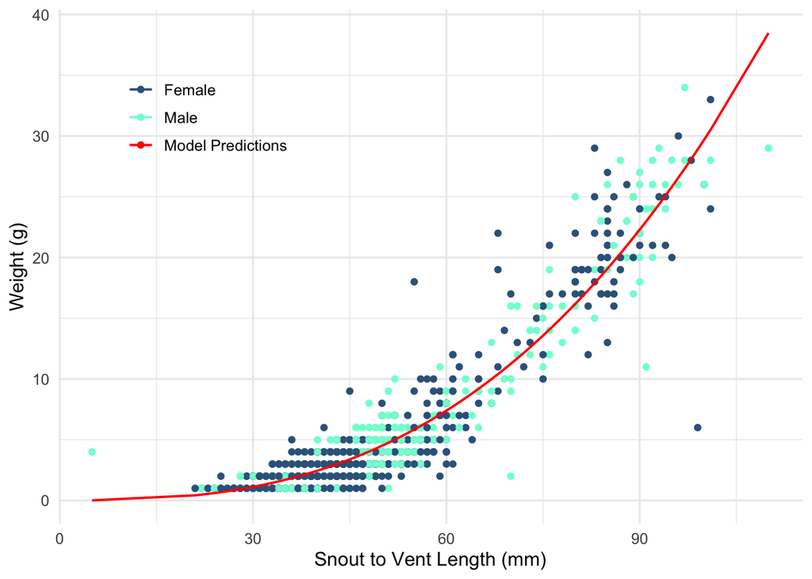

```r
# plotting the predicted data to actual data
ggplot() +
  geom_point(data = lizards, aes(
             x = sv_length,
             y = weight,
             color = sex)) +
  geom_line(data = lizards_augment, aes(
            x = sv_length,
            y = .fitted,
            color = "Model Predictions"),
            size = 0.7) +
  theme_minimal(12) +
  scale_color_manual(values = c("steelblue4", "aquamarine", "red")) +
  theme(legend.position = c(0.2,0.8), legend.title = element_blank()) +
  labs( x = "Snout to Vent Length (mm)", y = "Weight (g)")
```

```r
# calculating RMSE
lizards_rmse <- rmse(lizards_nls, data = lizards)
```

**Figure 1:** looks at snout to vent length and weight for all lizard species, colored by sex. The red line displays the NLS model which predicts weight as a function of snout to vent length. The root mean squared error (RMSE) for this NLS model is 1.563.

### Running NLS on male Western Whiptail lizards

```r
# filtering out male whiptails
whiptails <- lizards %>%
  filter(spp == "CNTI", sex == "Male")
```

```r
# running linear regression on log transformed data to estimate starting coefficients
guess_whiptails <- lm(log_weight ~ log_length, data = whiptails)

# tidy output of guess model
tidy_whiptails_guess <- tidy(guess_whiptails)

# pulling out coefficients for NLS
whiptails_coef <- coefficients(guess_whiptails)
```

**Coefficient Output**

- The intercept of `guess_whiptails` is -9.024
- The log_length of `guess_whiptails` is 2.698

```r
# running NLS whiptails
whiptails_nls <- nls(weight ~ weight_function(a, sv_length, b),
                  data = whiptails,
                  start = list(b = whiptails_coef[2], # starting from our guess coefficients
                               a = exp(whiptails_coef[1]))) # retransforming the intercept coefficient

# tidy output of model
whiptails_nls_tidy <- tidy(whiptails_nls)

whiptails_nls_tidy %>%
  mutate(p.value = case_when(p.value < 0.001 ~ '<0.001',
                             p.value > 0.001 ~ as.character(round(p.value, 3)))) %>%
  kable(col.names = c('Term', 'Coefficient', 'Standard Error', 'Statistic', 'P Value'), digits = 4, caption = '<b>Table 2:</b> Whiptail NLS Model Results') %>%
  kable_styling(bootstrap_options = c('striped', 'hover')) %>%
  kable_styling(full_width = FALSE)
```

**Table 2:** Whiptail NLS Model Results

| Term | Coefficient | Standard Error | Statistic | P Value |
| --- | --- | --- | --- | --- |
| b | 2.3683 | 0.1800 | 13.1547 | <0.001 |
| a | 0.0005 | 0.0004 | 1.2397 | 0.219 |

```r
# predicting data based on model
whiptails_augment <- augment(whiptails_nls)

# making a data frame with all data and predicted values for whiptails
whiptails_all <- data.frame(lizards, lizards_augment) %>%
  filter(spp == "CNTI", sex == "Male")
```

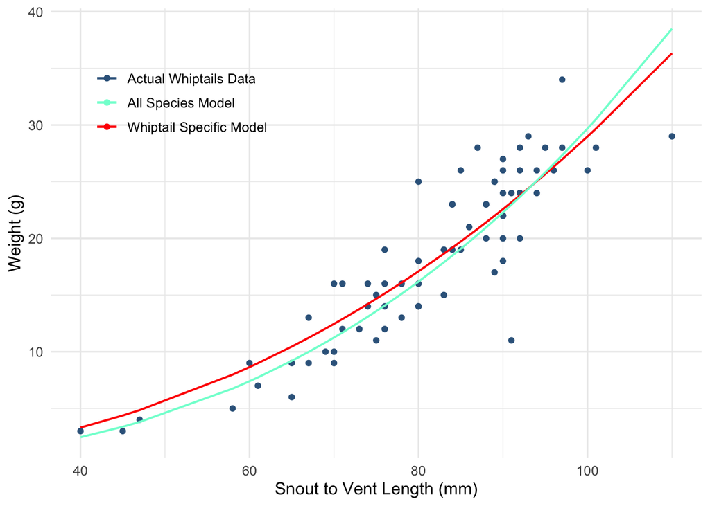

```r
# visualizing actual data against the fitted models
ggplot() +
  geom_point(data = whiptails, aes(
             x = sv_length,
             y = weight,
             color = 'Actual Whiptails Data')) +
  geom_line(data = whiptails_augment, aes(
            x = sv_length,
            y = .fitted,
            color = 'Whiptail Specific Model'),
            size = 0.7) +
  geom_line(data = whiptails_all, aes(
            x = sv_length,
            y = .fitted,
            color = 'All Species Model'),
            size = 0.7) +
  scale_color_manual(values = c('steelblue4', 'aquamarine', 'red')) +
  theme_minimal(12) +
  labs( x = "Snout to Vent Length (mm)", y = "Weight (g)") +
  theme(legend.title = element_blank(),
        legend.position = c(0.2, 0.8))
```

```r
# calculating RMSE
whiptails_rmse <- rmse(whiptails_nls, data = whiptails) # running whiptail model on whiptail subset
whiptails_rmse_all <- rmse(lizards_nls, data = whiptails) # running general model on whiptail data
```

**Figure 2:** compares the snout to vent length and weight of male western whiptail lizards. The red line displays the NLS model trend that was trained on the subset of data including only male whiptail lizards. The light blue line represents the NLS model trained on the entire data set. The root mean squared error (RMSE) of the model trained on the entire data set is 3.462; the RMSE of the whiptail specific model is 3.349. The whiptail specific model has a lower RMSE, signifying that this model is the best fit when predicting weight from snout to vent length of male western whiptail lizards.